# Explore US Bikeshare Data

2026-04-12

## Введение

В этом проекте анализируются данные велопроката за первое полугодие 2017 года для трёх городов США: **Чикаго**, **Нью-Йорк** и **Вашингтон**.

Цели анализа: - Определить наиболее популярное время поездок. - Выявить самые загруженные станции и маршруты. - Сравнить длительность поездок между городами. - Изучить демографические характеристики пользователей.

## Подготовка данных

Данные успешно загружены. Всего поездок: **900000**.

## 1. Популярное время поездок

```
## === ЧИКАГО ===
```

```
## Самый частый месяц:        июнь
```

```
## Самый частый день недели:  вторник
```

```
## Самый частый час:           17 :00
```

```
## === НЬЮ-ЙОРК ===
```

```
## Самый частый месяц:        июнь
```

```
## Самый частый день недели:  среда
```

```
## Самый частый час:           17 :00
```

```
## === ВАШИНГТОН ===
```

```
## Самый частый месяц:        июнь
```

```
## Самый частый день недели:  среда
```

```
## Самый частый час:           8 :00
```

### 📊 График: Распределение поездок по часам суток (Нью-Йорк)

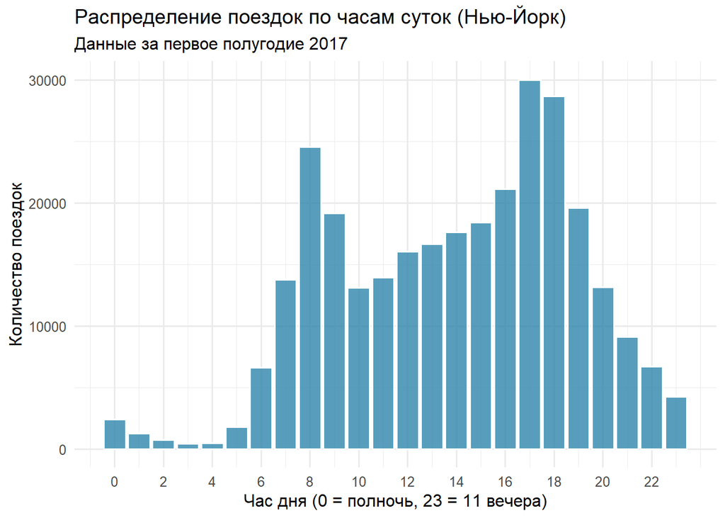

**Вывод:** Пик поездок приходится на утренние (7-9) и вечерние (16-18) часы — это соответствует часам пик, когда люди едут на работу и с работы.

## 2. Популярные станции и маршруты

```
## === ЧИКАГО ===
```

```
## Самая частая станция старта:
##    Streeter Dr & Grand Ave
```

```
## Самый частый маршрут:
##    Lake Shore Dr & Monroe St -> Streeter Dr & Grand Ave
```

```
## === НЬЮ-ЙОРК ===
```

```
## Самая частая станция старта:
##    Pershing Square North
```

```
## Самый частый маршрут:
##    E 7 St & Avenue A -> Cooper Square & E 7 St
```

```
## === ВАШИНГТОН ===
```

```
## Самая частая станция старта:
##    Columbus Circle / Union Station
```

```
## Самый частый маршрут:
##    Jefferson Dr & 14th St SW -> Jefferson Dr & 14th St SW
```

**Вывод:** Наиболее популярные станции расположены в центральных и туристических районах городов.